# R Notebook

## Bootstrapping and confidence intervals

### Learning Objectives

- Understand the concepts

```r
summary_popn
```

| mean_monthly_charges | mean_tenure | prop_churn |
| --- | --- | --- |
| 64.76169 | 32.37115 | 0.2653699 |

```r
summary_sample_200
```

| mean_monthly_charges | mean_tenure | prop_churn |
| --- | --- | --- |
| 59.61725 | 33.045 | 0.245 |

*confidence interval*

(**not right**) the range of values whitin which there is a 95% chance that the true population value lies.

Strictly, we can’t really say that

95% CI: really it’s about the *confidence* we have in our *CI*, as opposed to the confidence we would like to have in our estimate

```r
32.33624 + c(-1.770078, 170078)
```

```
[1]     30.56616 170110.33624
```

Think of this as like fishing with either a spear or a net.

The ‘spear’ is the point estimate,

while rhe ‘net’ is the confidence interval.

We generally talk in terms of a 95% CI or 99% CI

To be more certain of catching a fish, you have to make your net bigger. To have more confidence in the point estimate, you have to make the confidence interavl wider.

### Bootstrapping

Re-sampling **with** replacement

Why would we ever replace our samples?

```r
telco_200 <- read_csv("4_confidence_intervals/data/telecomms_churn_200_sample.csv") %>%
  clean_names()
glimpse(telco_200)
```

```
Rows: 200
Columns: 21
$ customer_id       <chr> "0799-DDIHE", "2587-EKXTS", "0708-SJDIS", "0071-NDAFP", "2885-HIJDH", "6959-GQEGV", "1468-DEFNC", "6559-RAKOZ", "6122-LJADA", "8652-YHIYU", "9069…
$ gender            <chr> "Female", "Male", "Female", "Male", "Male", "Male", "Male", "Male", "Male", "Female", "Male", "Female", "Female", "Female", "Female", "Female", "…
$ senior_citizen    <dbl> 0, 0, 0, 0, 0, 0, 1, 0, 0, 0, 0, 0, 0, 0, 1, 0, 0, 0, 0, 1, 0, 1, 0, 0, 0, 1, 0, 0, 0, 0, 0, 0, 0, 0, 0, 0, 0, 0, 0, 0, 0, 0, 0, 0, 0, 1, 0, 0, 0…
$ partner           <chr> "Yes", "No", "No", "Yes", "Yes", "No", "Yes", "Yes", "Yes", "No", "Yes", "No", "No", "No", "No", "No", "Yes", "Yes", "Yes", "Yes", "Yes", "No", "…
$ dependents        <chr> "Yes", "No", "No", "Yes", "Yes", "No", "Yes", "Yes", "Yes", "Yes", "No", "No", "No", "No", "No", "No", "Yes", "No", "No", "No", "Yes", "No", "No"…
$ tenure            <dbl> 15, 44, 34, 25, 69, 45, 64, 49, 70, 16, 23, 60, 28, 46, 15, 14, 17, 70, 51, 43, 55, 8, 53, 18, 1, 9, 72, 57, 71, 7, 8, 52, 7, 61, 2, 4, 18, 4, 15…
$ phone_service     <chr> "Yes", "Yes", "Yes", "Yes", "Yes", "Yes", "Yes", "Yes", "Yes", "Yes", "Yes", "Yes", "Yes", "Yes", "Yes", "Yes", "Yes", "Yes", "Yes", "Yes", "Yes"…
$ multiple_lines    <chr> "No", "Yes", "Yes", "Yes", "Yes", "No", "Yes", "Yes", "Yes", "Yes", "No", "Yes", "Yes", "No", "Yes", "No", "Yes", "Yes", "Yes", "No", "No", "No p…
$ internet_service  <chr> "DSL", "Fiber optic", "DSL", "No", "DSL", "DSL", "No", "Fiber optic", "DSL", "Fiber optic", "DSL", "DSL", "DSL", "Fiber optic", "Fiber optic", "F…
$ online_security   <chr> "No", "Yes", "No", "No internet service", "Yes", "Yes", "No internet service", "No", "Yes", "No", "Yes", "Yes", "Yes", "No", "No", "No", "Yes", "…
$ online_backup     <chr> "No", "Yes", "No", "No internet service", "No", "No", "No internet service", "No", "Yes", "No", "No", "No", "No", "No", "Yes", "Yes", "No", "No i…
$ device_protection <chr> "No", "Yes", "No", "No internet service", "Yes", "Yes", "No internet service", "No", "Yes", "No", "No", "Yes", "Yes", "Yes", "No", "No", "Yes", "…
$ tech_support      <chr> "No", "No", "Yes", "No internet service", "Yes", "No", "No internet service", "Yes", "Yes", "Yes", "No", "Yes", "No", "No", "No", "Yes", "No", "N…
$ streaming_tv      <chr> "No", "Yes", "Yes", "No internet service", "Yes", "Yes", "No internet service", "Yes", "Yes", "No", "No", "No", "No", "No", "No", "No", "Yes", "N…
$ streaming_movies  <chr> "No", "Yes", "No", "No internet service", "Yes", "Yes", "No internet service", "Yes", "Yes", "No", "Yes", "No", "No", "No", "Yes", "No", "Yes", "…
$ contract          <chr> "Month-to-month", "Month-to-month", "Month-to-month", "Two year", "Two year", "Month-to-month", "Two year", "One year", "Two year", "One year", "…
$ paperless_billing <chr> "No", "Yes", "No", "No", "No", "Yes", "Yes", "Yes", "Yes", "Yes", "Yes", "No", "No", "Yes", "No", "Yes", "Yes", "No", "Yes", "Yes", "No", "Yes", …
$ payment_method    <chr> "Electronic check", "Electronic check", "Mailed check", "Credit card (automatic)", "Bank transfer (automatic)", "Electronic check", "Bank transfe…
$ monthly_charges   <dbl> 46.30, 111.50, 65.00, 25.50, 86.90, 75.95, 24.40, 97.95, 90.15, 79.50, 59.95, 64.75, 59.00, 74.80, 89.85, 80.05, 104.20, 24.25, 111.55, 100.55, 7…
$ total_charges     <dbl> 639.45, 4915.15, 2157.50, 630.60, 6194.10, 3273.80, 1548.65, 4917.90, 6237.05, 1264.20, 1406.00, 4039.50, 1654.45, 3548.30, 1424.95, 1112.30, 174…
$ churn             <chr> "No", "No", "No", "No", "No", "No", "No", "No", "No", "No", "No", "No", "No", "No", "Yes", "No", "Yes", "No", "No", "No", "No", "Yes", "Yes", "No…
```

```r
bootstrap_resample_200 <- sample_200 %>%
  rep_sample_n(size = 200, replace = TRUE, reps = 5000) %>%
  summarise(
    mean_tenure = mean(tenure)
  )

bootstrap_resample_200
```

| replicate | mean_tenure |
| --- | --- |
| 1 | 32.105 |
| 2 | 34.805 |
| 3 | 33.940 |
| 4 | 30.865 |
| 5 | 30.605 |
| 6 | 33.280 |
| 7 | 32.185 |
| 8 | 32.980 |
| 9 | 32.565 |
| 10 | 34.090 |

[output cut: 990 more lines]

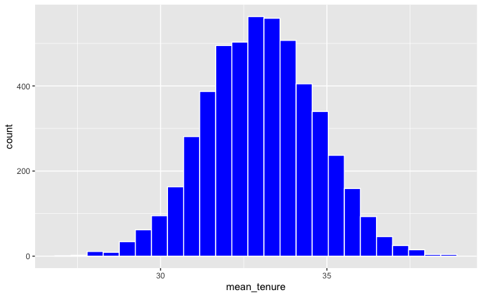

```r
bootstrap_resample_200 %>%
  ggplot(aes(x = mean_tenure)) +
  geom_histogram(bins = 25, colour = "white", fill = "blue")
```

[output not shown]

1. We resample with replacement, samples of the same size of our orginal sample
- we replace because if we didn’t all reps would be identical
  - if we resample beyond the size of our sample… -consider sampling 400
- If we resample with smaller sizes we’re giving up some possible information
- Rare values are rare, common values are common
  - with replacement, we are placing heavier weight on the common values

## CI from bs

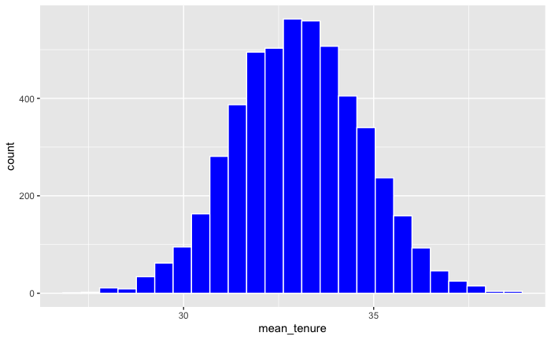

```r
bootstrap_resample_200 %>%
  ggplot(aes(x = mean_tenure)) +
  geom_histogram(bins = 25, colour = "white", fill = "blue")
```

A confidence interval is an interval that means it is composed of two limits

we want a 95%CI (0.025 = 2.5%)

```r
bootstrap_resample_200 %>%
  summarise(
    mean = mean(mean_tenure),
    lower_bound = quantile(mean_tenure, prob = 0.025),
    upper_bound = quantile(mean_tenure, prob = 0.975)
  )
```

| mean | lower_bound | upper_bound |
| --- | --- | --- |
| 33.02654 | 29.755 | 36.28025 |

### Working using the `infer` package

1. `specify()` which variable we are interested in (`tenure`)
2. `generate()` our replicate resamples
3. `calculate()` the summary stats we are interested in

How many obs do we have for each replicate? It’s 200 BECAUSE we are bootstrapping

```r
infer_resample
```

```
Response: tenure (numeric)
```

| replicate | stat |
| --- | --- |
| 1 | 31.765 |
| 2 | 35.015 |
| 3 | 34.735 |
| 4 | 34.590 |
| 5 | 30.720 |
| 6 | 30.600 |
| 7 | 35.095 |
| 8 | 33.640 |
| 9 | 29.610 |
| 10 | 34.010 |

[output cut: 990 more lines]

### Calculate our CI

we want to get the standard error of our sample means

| lower_ci | upper_ci |
| --- | --- |
| 29.23988 | 36.12012 |

[figure not shown]

```r
infer_resample %>%
  summarise(mean = mean(stat))
```

| mean |
| --- |
| 32.62545 |